# Agrupación con K-means

Hasta ahora trabajaste con problemas de aprendizaje supervisado, en los que cada observación estaba asociada con una etiqueta o un valor que el modelo debía predecir. En este tutorial abordarás un escenario diferente: la agrupación (*clustering*), un problema de aprendizaje no supervisado en el que no existe una variable objetivo. En este caso, el propósito es identificar similitudes entre las observaciones y organizarlas en grupos a partir de sus características. Para ello, utilizarás **K-means**, uno de los algoritmos de agrupación más conocidos y utilizados.

Seguimos el mismo mapa del proceso de *machine learning*: problema → datos → preparación → modelado → evaluación. Utilizaremos un conjunto de datos sobre el comportamiento de clientes con tarjetas de crédito para identificar perfiles según el uso que hacen de ellas.

> Trabajarás con datos reales de comportamiento financiero. Como los grupos obtenidos podrían apoyar decisiones sobre los clientes, es importante analizarlos no solo desde el punto de vista técnico, sino también considerando las implicaciones de su uso.

El notebook cubre los siguientes pasos:

1. Comprensión del problema
2. Comprensión de los datos
3. Limpieza y preparación.
4. Modelado.
5. Interpretación de los grupos.
6. Ejercicios

## 0. Importación de librerías requeridas

```python
import pandas as pd
import matplotlib.pyplot as plt
import matplotlib.animation as animation
import numpy as np
from IPython.display import HTML

from sklearn.impute import SimpleImputer
from sklearn.preprocessing import MinMaxScaler
from sklearn.metrics import silhouette_score
from sklearn.cluster import KMeans
from sklearn.datasets import make_blobs
from sklearn.pipeline import Pipeline
from sklearn.model_selection import GridSearchCV

from importlib.metadata import version

print(f"Versión de Pandas: {version('pandas')}")
print(f"Versión de Matplotlib: {version('matplotlib')}")
print(f"Versión de Scikit-learn: {version('scikit-learn')}")
print(f"Versión de Numpy: {version('numpy')}")
```

```
Versión de Pandas: 2.3.3
Versión de Matplotlib: 3.10.0
Versión de Scikit-learn: 1.7.2
Versión de Numpy: 2.3.5
```

## 1. Comprensión del problema

Trabajaremos con datos de comportamiento financiero de clientes de una entidad bancaria: cuánto gastan, con qué frecuencia usan su tarjeta y si solicitan avances de efectivo, entre otras variables. El objetivo es construir un modelo de agrupación que permita identificar perfiles de clientes según el uso que hacen de su tarjeta de crédito. Estos perfiles podrían servir como punto de partida para analizar estrategias diferenciadas de productos o servicios.

La pregunta que orienta el análisis es:

> **¿Existen grupos de clientes con comportamientos de uso similares entre sí?**

Ten en cuenta que, a diferencia de los problemas supervisados que has trabajado hasta ahora, aquí no existe una variable objetivo que el modelo deba predecir. Tampoco existe una única agrupación "correcta". El propósito del tutorial es aprender a construir, evaluar e interpretar una solución de agrupación con K-means, incluyendo la selección del número de grupos.

## 2. Comprensión de los datos

```python
data_raw = pd.read_csv('data/creditcard_data.csv', sep=',')
```

Veamos los primeros datos del conjunto utilizando `head()`:

```python
data_raw.head()
```

|  | CUST_ID | BALANCE | BALANCE_FREQUENCY | PURCHASES | ONEOFF_PURCHASES | INSTALLMENTS_PURCHASES | CASH_ADVANCE | PURCHASES_FREQUENCY | ONEOFF_PURCHASES_FREQUENCY | PURCHASES_INSTALLMENTS_FREQUENCY | CASH_ADVANCE_FREQUENCY | CASH_ADVANCE_TRX | PURCHASES_TRX | CREDIT_LIMIT | PAYMENTS | MINIMUM_PAYMENTS | PRC_FULL_PAYMENT | TENURE |
| --- | --- | --- | --- | --- | --- | --- | --- | --- | --- | --- | --- | --- | --- | --- | --- | --- | --- | --- |
| 0 | C10001 | 40.900749 | 0.818182 | 95.40 | 0.00 | 95.4 | 0.000000 | 0.166667 | 0.000000 | 0.083333 | 0.000000 | 0 | 2 | 1000.0 | 201.802084 | 139.509787 | 0.000000 | 12 |
| 1 | C10002 | 3202.467416 | 0.909091 | 0.00 | 0.00 | 0.0 | 6442.945483 | 0.000000 | 0.000000 | 0.000000 | 0.250000 | 4 | 0 | 7000.0 | 4103.032597 | 1072.340217 | 0.222222 | 12 |
| 2 | C10003 | 2495.148862 | 1.000000 | 773.17 | 773.17 | 0.0 | 0.000000 | 1.000000 | 1.000000 | 0.000000 | 0.000000 | 0 | 12 | 7500.0 | 622.066742 | 627.284787 | 0.000000 | 12 |
| 3 | C10004 | 1666.670542 | 0.636364 | 1499.00 | 1499.00 | 0.0 | 205.788017 | 0.083333 | 0.083333 | 0.000000 | 0.083333 | 1 | 1 | 7500.0 | 0.000000 | NaN | 0.000000 | 12 |
| 4 | C10005 | 817.714335 | 1.000000 | 16.00 | 16.00 | 0.0 | 0.000000 | 0.083333 | 0.083333 | 0.000000 | 0.000000 | 0 | 1 | 1200.0 | 678.334763 | 244.791237 | 0.000000 | 12 |

```python
data = data_raw.copy()
```

```python
data.shape
```

```
(8950, 18)
```

Se observa que el dataset está compuesto por $8950$ entradas donde cada una cuenta con 18 variables. Veamos el diccionario de estos datos:

Diccionario de los datos:

| Columna | Tipo | Descripción |
| --- | --- | --- |
| `CUST_ID` | categórica | Identificación del cliente |
| `BALANCE` | numérica | Cantidad de dinero disponible en la cuenta |
| `BALANCE_FREQUENCY` | numérica | Frecuencia de actualización del balance (0 = poco frecuente, 1 = muy frecuente) |
| `PURCHASES` | numérica | Valor de compras |
| `ONEOFF_PURCHASES` | numérica | Valor de compras realizadas en un pago |
| `INSTALLMENTS_PURCHASES` | numérica | Valor de compras realizadas en cuotas |
| `CASH_ADVANCE` | numérica | Avances de dinero dados |
| `PURCHASES_FREQUENCY` | numérica | Frecuencia de compras (0 = poco frecuente, 1 = muy frecuente) |
| `ONEOFF_PURCHASES_FREQUENCY` | numérica | Frecuencia de compras realizadas en un pago (0 = poco frecuente, 1 = muy frecuente) |
| `PURCHASES_INSTALLMENTS_FREQUENCY` | numérica | Frecuencia de compras realizadas en cuotas (0 = poco frecuente, 1 = muy frecuente) |
| `CASH_ADVANCE_FREQUENCY` | numérica | Frecuencia de avances de dinero (0 = poco frecuente, 1 = muy frecuente) |
| `CASH_ADVANCE_TRX` | numérica | Número de transacciones realizadas con dinero de avances |
| `PURCHASES_TRX` | numérica | Número de compras realizadas |
| `CREDIT_LIMIT` | numérica | Límite de la tarjeta de crédito |
| `PAYMENTS` | numérica | Cantidad de dinero abonado en pagos |
| `MINIMUM_PAYMENTS` | numérica | Mínimo pago realizado |
| `PRC_FULL_PAYMENT` | numérica | Porcentaje de pago de compras |
| `TENURE` | numérica | Tenencia del servicio |

### ¿De dónde vienen estos datos?

Este conjunto de datos resume el comportamiento de uso de aproximadamente 9000 tarjetahabientes activos durante un período de 6 meses, recolectado originalmente para un ejercicio de segmentación de clientes con fines de marketing. No se conoce con precisión la entidad bancaria ni el país de origen de estos clientes, lo cual es importante tener en cuenta, ya que los hábitos de consumo con tarjeta de crédito pueden variar mucho según el contexto económico y cultural, por lo que los grupos que encontremos aplican a esta población específica y no necesariamente se generalizan a otros mercados o segmentos de clientes. (*Datos*: Credit Card Dataset for Clustering. Fuente: https://www.kaggle.com/datasets/arjunbhasin2013/ccdata. Licencia Creative Common.)

### Verificación de la calidad de los datos

Primero utilizaremos `data.describe()` para obtener una descripción general de las variables.

```python
data.describe()
```

|  | BALANCE | BALANCE_FREQUENCY | PURCHASES | ONEOFF_PURCHASES | INSTALLMENTS_PURCHASES | CASH_ADVANCE | PURCHASES_FREQUENCY | ONEOFF_PURCHASES_FREQUENCY | PURCHASES_INSTALLMENTS_FREQUENCY | CASH_ADVANCE_FREQUENCY | CASH_ADVANCE_TRX | PURCHASES_TRX | CREDIT_LIMIT | PAYMENTS | MINIMUM_PAYMENTS | PRC_FULL_PAYMENT | TENURE |
| --- | --- | --- | --- | --- | --- | --- | --- | --- | --- | --- | --- | --- | --- | --- | --- | --- | --- |
| count | 8950.000000 | 8950.000000 | 8950.000000 | 8950.000000 | 8950.000000 | 8950.000000 | 8950.000000 | 8950.000000 | 8950.000000 | 8950.000000 | 8950.000000 | 8950.000000 | 8949.000000 | 8950.000000 | 8637.000000 | 8950.000000 | 8950.000000 |
| mean | 1564.474828 | 0.877271 | 1003.204834 | 592.437371 | 411.067645 | 978.871112 | 0.490351 | 0.202458 | 0.364437 | 0.135144 | 3.248827 | 14.709832 | 4494.449450 | 1733.143852 | 864.206542 | 0.153715 | 11.517318 |
| std | 2081.531879 | 0.236904 | 2136.634782 | 1659.887917 | 904.338115 | 2097.163877 | 0.401371 | 0.298336 | 0.397448 | 0.200121 | 6.824647 | 24.857649 | 3638.815725 | 2895.063757 | 2372.446607 | 0.292499 | 1.338331 |
| min | 0.000000 | 0.000000 | 0.000000 | 0.000000 | 0.000000 | 0.000000 | 0.000000 | 0.000000 | 0.000000 | 0.000000 | 0.000000 | 0.000000 | 50.000000 | 0.000000 | 0.019163 | 0.000000 | 6.000000 |
| 25% | 128.281915 | 0.888889 | 39.635000 | 0.000000 | 0.000000 | 0.000000 | 0.083333 | 0.000000 | 0.000000 | 0.000000 | 0.000000 | 1.000000 | 1600.000000 | 383.276166 | 169.123707 | 0.000000 | 12.000000 |
| 50% | 873.385231 | 1.000000 | 361.280000 | 38.000000 | 89.000000 | 0.000000 | 0.500000 | 0.083333 | 0.166667 | 0.000000 | 0.000000 | 7.000000 | 3000.000000 | 856.901546 | 312.343947 | 0.000000 | 12.000000 |
| 75% | 2054.140036 | 1.000000 | 1110.130000 | 577.405000 | 468.637500 | 1113.821139 | 0.916667 | 0.300000 | 0.750000 | 0.222222 | 4.000000 | 17.000000 | 6500.000000 | 1901.134317 | 825.485459 | 0.142857 | 12.000000 |
| max | 19043.138560 | 1.000000 | 49039.570000 | 40761.250000 | 22500.000000 | 47137.211760 | 1.000000 | 1.000000 | 1.000000 | 1.500000 | 123.000000 | 358.000000 | 30000.000000 | 50721.483360 | 76406.207520 | 1.000000 | 12.000000 |

La tabla permite nos permite visualizar varias cosas:

- La fila `count`muestra valores faltantes en `CREDIT_LIMIT` y `MINIMUM_PAYMENTS`, y el máximo de `CASH_ADVANCE_FREQUENCY` (1,5) supera el rango válido de una frecuencia.
- Las escalas son muy distintas.
- Las variables de montos son muy asimétricas, se puede ver que en PURCHASES, por ejemplo, la mediana es 361, la media 1.003 y el máximo 49.040, lo que indica que unos pocos clientes concentran valores muy altos.
- También llaman la atención los ceros, más de la mitad de los clientes nunca usó avances en efectivo, cerca de una cuarta parte no hizo compras y la mayoría nunca pagó el total de su tarjeta. Esto sugiere que existen formas muy distintas de usar la tarjeta, algo que la agrupación nos puede a ayudar a explorar.

#### Verificación de unicidad

```python
n_duplicadas = data.duplicated().sum()
print(f"Filas idénticas (duplicadas): {n_duplicadas}")
```

```
Filas idénticas (duplicadas): 0
```

#### Verificación de la completitud

```python
data.isna().sum()
```

```
CUST_ID                               0
BALANCE                               0
BALANCE_FREQUENCY                     0
PURCHASES                             0
ONEOFF_PURCHASES                      0
INSTALLMENTS_PURCHASES                0
CASH_ADVANCE                          0
PURCHASES_FREQUENCY                   0
ONEOFF_PURCHASES_FREQUENCY            0
PURCHASES_INSTALLMENTS_FREQUENCY      0
CASH_ADVANCE_FREQUENCY                0
CASH_ADVANCE_TRX                      0
PURCHASES_TRX                         0
CREDIT_LIMIT                          1
PAYMENTS                              0
MINIMUM_PAYMENTS                    313
PRC_FULL_PAYMENT                      0
TENURE                                0
dtype: int64
```

Como puedes observar, se tienen ausencias en las variables `CREDIT_LIMIT` y `MINIMUM_PAYMENTS`. En lugar de eliminarlos, utilizaremos `SimpleImputer` con la `mediana`. Esta medida es menos sensible que la media a distribuciones asimétricas y a valores extremos, características presentes en varias de las variables financieras de este conjunto de datos.

#### Verificación de consistencia

```python
data.dtypes
```

```
CUST_ID                              object
BALANCE                             float64
BALANCE_FREQUENCY                   float64
PURCHASES                           float64
ONEOFF_PURCHASES                    float64
INSTALLMENTS_PURCHASES              float64
CASH_ADVANCE                        float64
PURCHASES_FREQUENCY                 float64
ONEOFF_PURCHASES_FREQUENCY          float64
PURCHASES_INSTALLMENTS_FREQUENCY    float64
CASH_ADVANCE_FREQUENCY              float64
CASH_ADVANCE_TRX                      int64
PURCHASES_TRX                         int64
CREDIT_LIMIT                        float64
PAYMENTS                            float64
MINIMUM_PAYMENTS                    float64
PRC_FULL_PAYMENT                    float64
TENURE                                int64
dtype: object
```

Los tipos de datos corresponden con lo que representa cada variable. El identificador es texto, los conteos y la antigüedad son enteros, y los montos y frecuencias son decimales. Según la tabla de describe(), cada columna usa una sola unidad de medida, las frecuencias y PRC_FULL_PAYMENT están entre 0 y 1 (salvo los casos de CASH_ADVANCE_FREQUENCY que se revisan en validez), y TENURE está en meses. No se observan problemas de consistencia.

#### Verificación de la validez

Revisamos que los valores de cada variable sean coherentes con su significado. Los montos y conteos no presentan valores negativos y TENURE se encuentra entre 6 y 12 meses. Las variables de frecuencia y PRC_FULL_PAYMENT deben estar entre 0 y 1; únicamente CASH_ADVANCE_FREQUENCY presenta 8 registros fuera de este rango, que serán eliminados. Aunque las variables de montos presentan valores extremos, estos son plausibles para clientes con alta actividad, por lo que se conservarán como valores atípicos reales.

## 3. Limpieza y preparación de los datos

#### Tratamiento de ausencias

```python
imputer = SimpleImputer(missing_values=np.nan, strategy='median')
```

#### Tratamiento de valores invalidos

```python
# Se identifican los registros con valores fuera del rango válido [0, 1]
indices_invalidos = data[~data["CASH_ADVANCE_FREQUENCY"].between(0, 1)].index
# Se eliminan estos registros
data.drop(index=indices_invalidos, inplace=True)
```

#### Eliminación de variables poco relevantes

Este conjunto de datos solo tiene una variable poco relevante para realizar la agrupación: `CUST_ID`. Haciendo uso de la función `drop()`, eliminaremos esta variable del DataFrame:

```python
data = data.drop('CUST_ID', axis=1)
```

#### Escalado de variables

K-Means se basa en distancias. Si una variable tiene valores en [0, 10.000] y otra en [0, 1], la primera dominara el cálculo de distancias por pura magnitud, sin importar que tan informativa sea realmente.

Utilizaremos MinMaxScaler(), que lleva cada variable al rango [0, 1]. Seis de nuestras variables (las frecuencias y PRC_FULL_PAYMENT) ya están en esa escala, por lo que este escalador las conserva tal como están y lleva los montos a la misma escala. Esta elección es coherente con nuestra pregunta, que busca grupos según el uso de la tarjeta, algo que describen directamente esas variables. Ten en cuenta que, como los montos tienen unos pocos valores muy extremos, quedarán comprimidos cerca de 0 y pesarán menos en la agrupación. Lo comprobaremos al interpretar los grupos.

```python
scaler = MinMaxScaler().set_output(transform="pandas")
```

## 4. Modelado

### ¿Cómo funciona K-means?

1. **Inicialización:** elige *k* puntos como centroides iniciales.
2. **Asignación:** asigna cada dato al centroide más cercano.
3. **Actualización:** mueve cada centroide al promedio de los datos que le fueron asignados.
4. **Convergencia:** repite los pasos 2 y 3 hasta que los centroides prácticamente dejan de moverse.

Inicialmente crearemos un objeto de la clase `KMeans` para ejecutar el algoritmo de agrupación. Especificaremos un máximo de iteraciones con el parámetro `max_iter` y la semilla con el parámetro `random_state`:

```python
kmeans = KMeans(max_iter=300, random_state=0)
```

Posteriormente, construiremos nuestro pipeline de procesamiento y entrenamiento con los objetos `imputer`, `scaler` y `kmeans`, también configuramos `.set_output(transform="pandas")` para luego ver algunos datos útiles que contendrá el modelo resultante:

```python
pipe = Pipeline(steps=[("imputer", imputer), ("scaler", scaler), ("model", kmeans)]).set_output(transform="pandas")
```

### 4.1. Selección del hiperparámetro K

Antes de entrenar el modelo final necesitamos decidir cuántos grupos (*k*) vamos a formar, es decir, el hiperparámetro `n_clusters` de `KMeans`. Usaremos dos criterios complementarios:

- **Método del codo:** grafica la **inercia** (suma de las distancias al cuadrado de cada dato a su centroide) para distintos valores de *k*. La inercia siempre disminuye al agregar grupos, así que buscamos el punto a partir del cual agregar un grupo más reduce poco la inercia.
- **Coeficiente de la silueta:** mide qué tan compactos y separados están los grupos resultantes. Valores más altos indican, en general, una mejor separación relativa entre grupos.

Para comparar varios valores de *k*, definimos la función `evaluar_k()`. La idea es la siguiente: para cada valor de *k* en el rango que definamos,

1. Le indicamos al pipeline que use ese valor de *k* (`pipe.set_params(model__n_clusters=i)`).
2. Entrenamos el pipeline completo con `pipe.fit(data)`: esto imputa los nulos, escala las variables y ejecuta KMeans con el número de grupos indicado, en un solo paso.
3. Guardamos la inercia del modelo entrenado, disponible en el atributo `inertia_`.
4. El coeficiente de la silueta necesita los datos ya imputados y escalados, no los originales. En vez de repetir esos pasos por fuera del pipeline (lo que además podría introducir inconsistencias si algo cambia en el `imputer` o el `scaler`), se los pedimos directamente al pipeline con `pipe[:-1].transform(data)`, que aplica todos los pasos del pipeline menos el último (el modelo). Así garantizamos que la silueta se calcule exactamente sobre los mismos datos que usó KMeans para formar los grupos.
5. Calculamos `silhouette_score()` con esos datos transformados y las etiquetas (`labels_`) que asignó el modelo, y guardamos el resultado.

Al final, graficamos la inercia y el coeficiente de la silueta obtenidos para cada valor de *k*:

```python
def evaluar_k(data, k_min=2, k_max=5):
    """
    Grafica la inercia (método del codo) y el coeficiente de la silueta para cada valor de k

    Parametros:
    data : pd.DataFrame
        El conjunto de datos original (sin imputar ni escalar)
    k_min : int
        Valor mínimo para k
    k_max : int
        Valor máximo para k
    """
    ks = range(k_min, k_max + 1)
    inercias, siluetas = [], []
    for i in ks:
        # Modificamos el parámetro k
        pipe.set_params(model__n_clusters=i).set_output(transform="pandas")
        # Ejecutamos el pipeline completo: imputación, escalado y KMeans
        pipe.fit(data)
        # Guardamos la inercia del modelo
        inercias.append(pipe['model'].inertia_)
        # Reutilizamos el pipeline para obtener los datos ya imputados y escalados
        clean_data = pipe[:-1].transform(data)
        # Calculamos el coeficiente de la silueta sobre esos mismos datos
        siluetas.append(silhouette_score(clean_data, pipe['model'].labels_))

    fig, axes = plt.subplots(1, 2, figsize=(13, 4))
    axes[0].plot(ks, inercias, marker='o')
    axes[0].set(xlabel='Número de clusters', ylabel='Inercia', title='Método del codo')
    axes[1].plot(ks, siluetas, marker='o', color='tab:orange')
    axes[1].set(xlabel='Número de clusters', ylabel='Silhouette Score', title='Coeficiente de la silueta')
    for ax in axes:
        ax.grid()
    plt.tight_layout()
    plt.show()

    return pd.DataFrame({'k': ks, 'inercia': inercias, 'silueta': siluetas}).round(3)
```

Veremos el comportamiento de ambos criterios para nuestro conjunto de datos:

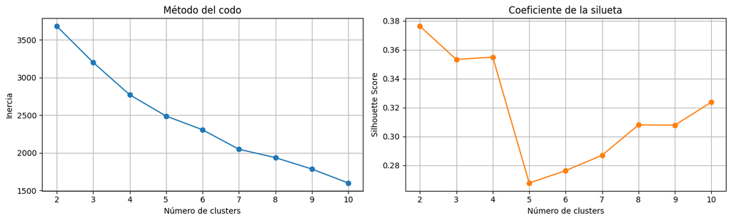

|  | k | inercia | silueta |
| --- | --- | --- | --- |
| 0 | 2 | 3680.255 | 0.376 |
| 1 | 3 | 3198.503 | 0.353 |
| 2 | 4 | 2771.645 | 0.355 |
| 3 | 5 | 2488.728 | 0.268 |
| 4 | 6 | 2306.978 | 0.276 |
| 5 | 7 | 2048.611 | 0.287 |
| 6 | 8 | 1937.959 | 0.308 |
| 7 | 9 | 1786.564 | 0.308 |
| 8 | 10 | 1601.538 | 0.324 |

```python
evaluar_k(data, 2, 10)
```

Como puedes observar, el codo es poco marcado, la inercia cae alrededor de un 13 % con cada grupo adicional hasta k=4, y a partir de ahí las reducciones son menores e irregulares. Esto es frecuente en datos reales, donde los clientes no forman nubes claramente separadas.

El coeficiente de la silueta es más alto con **k=2** (0,376), seguido muy de cerca por **k=4** (0,355) y **k=3** (0,353). Con k=5 baja a 0,268 y para valores mayores se mantiene por debajo de los tres primeros. Ten en cuenta que valores de silueta entre 0,25 y 0,50 suelen interpretarse como una estructura de grupos **débil**, donde los grupos existen, pero con fronteras difusas.

Como la silueta prácticamente no distingue entre k=2, 3 y 4, la decisión debe apoyarse también en la utilidad de la segmentación para el problema. En el resto del tutorial exploraremos la solución con **k=3**, que ofrece más detalle que k=2 sin perder separación. Esta elección no significa que k=3 sea "mejor" en términos absolutos, sino que es una alternativa razonable dentro del rango que sugieren ambos criterios.

## 5. Interpretación de los grupos

Ahora ajustaremos el modelo con k=3 para analizar los perfiles que produce esta solución. También reconfiguramos `.set_output(transform="pandas")` porque `scikit-learn` puede reemplazar el tipo de salida del pipeline al modificar los hiperparámetros mediante `set_params()`:

```python
pipe.set_params(model__n_clusters=3).set_output(transform="pandas")
pipe.fit(data)
```

```
Pipeline(steps=[('imputer', SimpleImputer(strategy='median')),
                ('scaler', MinMaxScaler()),
                ('model', KMeans(n_clusters=3, random_state=0))])
```

Primero veremos cuántos datos hay en cada grupo, lo que nos indicará qué tantos clientes tienen comportamientos similares. Para esto utilizaremos el atributo `labels_`, que retorna un arreglo con el índice del grupo al que pertenece cada dato. Además usaremos la función `unique()` de `numpy`, que retorna los valores únicos (que almacenamos en la variable `indexes`) y la cantidad de datos por cada uno (que almacenamos en la variable `values`):

```python
labels = pipe['model'].labels_
indexes, values = np.unique(labels, return_counts=True)

#{indexes[i]: values[i] for i in range(len(indexes))}
pd.DataFrame(zip(indexes,values),columns=["id del grupo","cantidad de datos"])
```

|  | id del grupo | cantidad de datos |
| --- | --- | --- |
| 0 | 0 | 3067 |
| 1 | 1 | 1195 |
| 2 | 2 | 4680 |

También podemos usar `plt.bar()` para graficar estos valores:

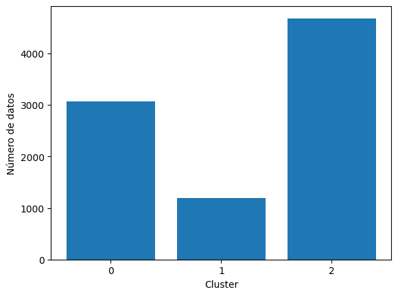

```python
rects = plt.bar(indexes, values)
plt.xlabel('Cluster')
plt.ylabel('Número de datos')
plt.xticks(indexes)
plt.show()
```

A continuación, obtendremos los centroides de cada grupo con el atributo `cluster_centers_` del objeto `kmeans`.

```python
centroids = pipe['model'].cluster_centers_
centroids = pd.DataFrame(centroids,columns=pipe[1].get_feature_names_out())
centroids
```

|  | BALANCE | BALANCE_FREQUENCY | PURCHASES | ONEOFF_PURCHASES | INSTALLMENTS_PURCHASES | CASH_ADVANCE | PURCHASES_FREQUENCY | ONEOFF_PURCHASES_FREQUENCY | PURCHASES_INSTALLMENTS_FREQUENCY | CASH_ADVANCE_FREQUENCY | CASH_ADVANCE_TRX | PURCHASES_TRX | CREDIT_LIMIT | PAYMENTS | MINIMUM_PAYMENTS | PRC_FULL_PAYMENT | TENURE |
| --- | --- | --- | --- | --- | --- | --- | --- | --- | --- | --- | --- | --- | --- | --- | --- | --- | --- |
| 0 | 0.096179 | 0.942684 | 0.034660 | 0.022089 | 0.035541 | 0.015587 | 0.887221 | 0.323511 | 0.735660 | 0.100398 | 0.020487 | 0.080177 | 0.160027 | 0.039269 | 0.014466 | 0.058699 | 0.942579 |
| 1 | 0.010313 | 0.867219 | 0.040173 | 0.028214 | 0.036473 | 0.001491 | 0.818700 | 0.333087 | 0.621925 | 0.012909 | 0.002513 | 0.071011 | 0.167310 | 0.041049 | 0.002651 | 0.813251 | 0.909827 |
| 2 | 0.091008 | 0.836779 | 0.006146 | 0.006110 | 0.002335 | 0.028981 | 0.146997 | 0.089869 | 0.056011 | 0.187300 | 0.036181 | 0.007892 | 0.135798 | 0.029085 | 0.010964 | 0.047999 | 0.908013 |

Como puedes observar, los centroides están escalados porque incluimos el paso del `scaler` en nuestro pipeline. Para obtener valores que sean interpretables con los rangos iniciales de los datos, utilizaremos la función `inverse_transform()`:

```python
centroids_transformed = scaler.inverse_transform(centroids)
centroids_transformed = pd.DataFrame(centroids_transformed,columns=pipe[1].get_feature_names_out())
centroids_transformed
```

|  | BALANCE | BALANCE_FREQUENCY | PURCHASES | ONEOFF_PURCHASES | INSTALLMENTS_PURCHASES | CASH_ADVANCE | PURCHASES_FREQUENCY | ONEOFF_PURCHASES_FREQUENCY | PURCHASES_INSTALLMENTS_FREQUENCY | CASH_ADVANCE_FREQUENCY | CASH_ADVANCE_TRX | PURCHASES_TRX | CREDIT_LIMIT | PAYMENTS | MINIMUM_PAYMENTS | PRC_FULL_PAYMENT | TENURE |
| --- | --- | --- | --- | --- | --- | --- | --- | --- | --- | --- | --- | --- | --- | --- | --- | --- | --- |
| 0 | 1831.552743 | 0.942684 | 1699.706346 | 900.391323 | 799.665186 | 734.706361 | 0.887221 | 0.323511 | 0.735660 | 0.100398 | 2.519883 | 28.703390 | 4842.819657 | 1991.791409 | 1105.345842 | 0.058699 | 11.655476 |
| 1 | 196.399096 | 0.867219 | 1970.089506 | 1150.039439 | 820.652228 | 70.288273 | 0.818700 | 0.333087 | 0.621925 | 0.012909 | 0.309045 | 25.422111 | 5060.932059 | 2082.079469 | 202.551126 | 0.813251 | 11.458961 |
| 2 | 1733.071348 | 0.836779 | 301.394034 | 249.058453 | 52.526468 | 1366.075523 | 0.146997 | 0.089869 | 0.056011 | 0.187300 | 4.450214 | 2.825214 | 4117.137723 | 1475.214154 | 837.745942 | 0.047999 | 11.448077 |

Con los centroides en la escala original, podemos caracterizar los tres grupos:

- **Grupo 0 — Compradores frecuentes a cuotas (3.067 clientes):** compran con mucha frecuencia (`PURCHASES_FREQUENCY` ≈ 0,89), sobre todo a cuotas (`PURCHASES_INSTALLMENTS_FREQUENCY` ≈ 0,74). Mantienen un saldo alto y casi nunca pagan el total de su tarjeta (`PRC_FULL_PAYMENT` ≈ 0,06).
- **Grupo 1 — Compradores frecuentes que pagan el total (1.195 clientes):** también compran con frecuencia y por montos similares a los del grupo 0, pero pagan el total de su tarjeta en la mayoría de los periodos (`PRC_FULL_PAYMENT` ≈ 0,81). Por eso su saldo es muy bajo, y casi no usan avances en efectivo.
- **Grupo 2 — Usuarios de avances en efectivo (4.680 clientes):** es el grupo más grande. Casi no compran con la tarjeta (`PURCHASES_FREQUENCY` ≈ 0,15) y son quienes más usan los avances en efectivo (`CASH_ADVANCE` y `CASH_ADVANCE_FREQUENCY` más altos). Rara vez pagan el total.

Observa que el límite de crédito (`CREDIT_LIMIT`) y los pagos (`PAYMENTS`) son relativamente parecidos en los tres grupos. Esto fue anticipado al escalar, las variables de montos casi no participaron en la formación de los grupos.

Estos perfiles describen **patrones de uso** de la tarjeta durante seis meses, no la situación financiera de las personas. Podría ser tentador leer "usuarios de avances" o "no pagan el total" como "clientes con dificultades" o "clientes riesgosos", pero la agrupación no sabe por qué alguien retira efectivo ni si puede pagar, un cliente puede usar avances por comodidad y otro por necesidad. Por eso, estos grupos no deberían utilizarse por sí solos para inferir el riesgo crediticio de una persona ni para tomar decisiones individuales sobre ella.

Para complementar la información de los centroides, podemos visualizar la distribución de algunas variables en cada grupo mediante boxplots. Esto permite observar no solo el valor central de cada grupo, sino también su dispersión, heterogeneidad y presencia de valores atípicos. Esta información es especialmente relevante porque un centroide resume al grupo, pero no describe exactamente a cada uno de sus integrantes.

Para ello, añadimos la etiqueta del grupo a los datos originales (sin escalar) y utilizamos `boxplot()` de Pandas. Incluimos cuatro variables que caracterizan los perfiles y dos variables de montos (`BALANCE` y `PURCHASES`) para observar qué tanto distinguen a los grupos:

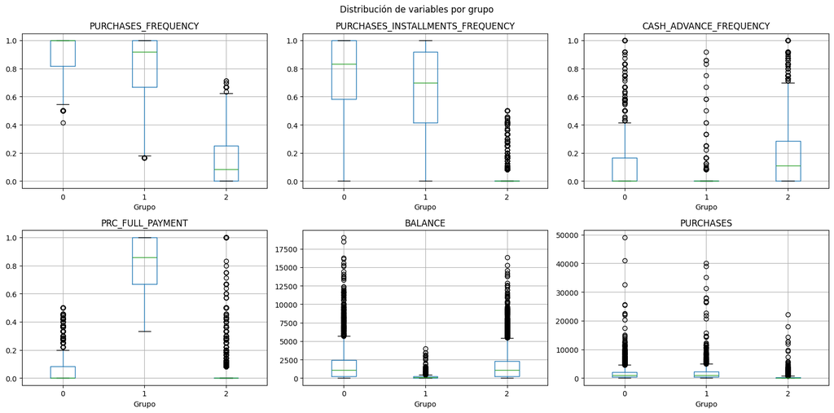

```python
data_con_grupo = data.copy()
data_con_grupo['grupo'] = labels

variables_interes = ['PURCHASES_FREQUENCY', 'PURCHASES_INSTALLMENTS_FREQUENCY', 'CASH_ADVANCE_FREQUENCY',
                     'PRC_FULL_PAYMENT', 'BALANCE', 'PURCHASES']

fig, axes = plt.subplots(2, 3, figsize=(16, 8))

for ax, variable in zip(axes.flat, variables_interes):
    data_con_grupo.boxplot(column=variable, by='grupo', ax=ax)
    ax.set_title(variable)
    ax.set_xlabel('Grupo')

plt.suptitle('Distribución de variables por grupo')
plt.tight_layout()
plt.show()
```

Podemos comprobar también por qué las variables de montos pesaron poco: después de aplicar `MinMaxScaler`, la varianza de las variables de frecuencia es decenas de veces mayor que la de las variables de montos.

```python
pipe[:-1].transform(data).var().sort_values(ascending=False).round(4)
```

```
PURCHASES_FREQUENCY                 0.1611
PURCHASES_INSTALLMENTS_FREQUENCY    0.1580
ONEOFF_PURCHASES_FREQUENCY          0.0891
PRC_FULL_PAYMENT                    0.0856
BALANCE_FREQUENCY                   0.0562
TENURE                              0.0494
CASH_ADVANCE_FREQUENCY              0.0391
CREDIT_LIMIT                        0.0148
BALANCE                             0.0119
PURCHASES_TRX                       0.0048
PAYMENTS                            0.0033
CASH_ADVANCE_TRX                    0.0031
CASH_ADVANCE                        0.0020
PURCHASES                           0.0019
ONEOFF_PURCHASES                    0.0017
INSTALLMENTS_PURCHASES              0.0016
MINIMUM_PAYMENTS                    0.0009
dtype: float64
```

Los boxplots confirman los perfiles: `PURCHASES_FREQUENCY` y `PURCHASES_INSTALLMENTS_FREQUENCY` separan claramente al grupo 2 (casi sin compras) de los otros dos, y `PRC_FULL_PAYMENT` distingue al grupo 1 (que paga el total) del grupo 0. En las variables de montos la situación es distinta. En `BALANCE`, el grupo 1 tiene saldos más bajos (consecuencia de pagar el total), pero los grupos 0 y 2 son prácticamente iguales. En `PURCHASES`, las cajas de los tres grupos quedan comprimidas cerca de cero y la escala la dominan unos pocos valores extremos. Estas variables aportan poco a la separación de los grupos, como anticipamos al escalar.

Los gráficos también muestran una variabilidad considerable y numerosos valores extremos dentro de los grupos, lo que recuerda que el centroide representa un comportamiento promedio y no necesariamente describe a todos sus integrantes.

Esto recuerda que **pertenecer al mismo clúster no significa que dos clientes sean iguales**: el grupo resume similitudes relativas dentro del conjunto de variables utilizadas.

## 6. Ejercicios

Ya identificamos tres perfiles de clientes según su comportamiento con la tarjeta de crédito. Antes de cerrar, vale la pena pensar en cómo podría utilizarse este resultado en la práctica:

- Si tuvieras que explicar estos tres grupos a un equipo de negocio sin utilizar los nombres de las variables originales (`CASH_ADVANCE`, `PURCHASES_FREQUENCY`, etc.), ¿qué nombre y descripción le darías a cada uno?
- Supón que el banco decide usar estos grupos para ofrecer más avances en efectivo a los clientes del grupo 2, porque son quienes más los usan. ¿A quién beneficia esa decisión? ¿Qué podría salir mal para esos clientes? ¿Qué riesgos tiene tratar a todas las personas de un mismo grupo de la misma manera?
- Elegimos **k=3** para explorar una segmentación más detallada, aunque k=2 obtuvo una silueta ligeramente más alta. ¿Cómo podrían cambiar la interpretación y las decisiones asociadas si hubiéramos elegido k=2 o k=4?
- Reemplaza `MinMaxScaler` por `StandardScaler` y luego por `RobustScaler`, y vuelve a ejecutar el modelado con k=3. Para cada uno, observa el tamaño de los grupos, el coeficiente de la silueta y los perfiles que se obtienen. ¿Qué variables pesan más con cada escalador? ¿Un mismo cliente quedaría en un grupo con el mismo significado? ¿Qué te dice esto sobre el peso que tienen las decisiones de preparación de datos en el resultado, y sobre lo que debería saber quien tome decisiones a partir de estos grupos?